# TSWomen

Romanova

27 февраля 2019 г

# 1 Анализ конкретного временного ряда

## 1.1 Общие вещи

Рассматриваемый ряд – уровень женской безработицы с 1948 по 2018 год, измеренный в процентах неработающих женщин относительно всех женщин, которые имеют возможность работать.

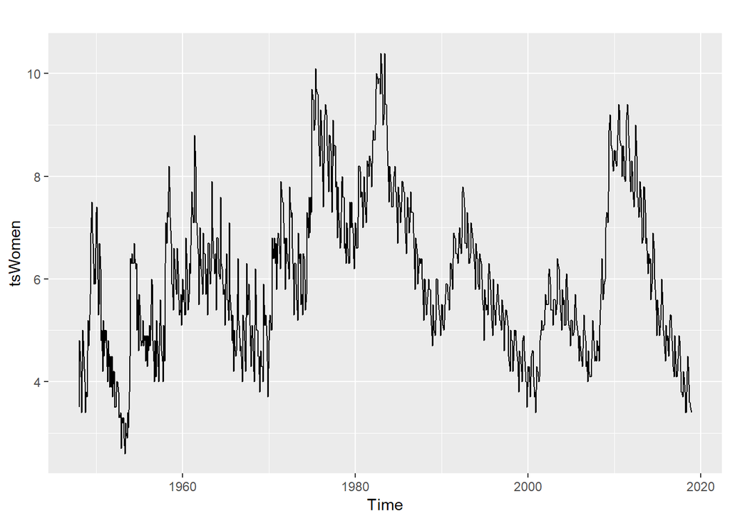

```r
tsWomen<-ts(TS.data$Value, frequency = 12, start = 1948)
autoplot(tsWomen)
```

Модель ряда скорее всего нельзя назвать ни аддитивной, ни мультипликативной. На графике можно заметить, что колебания сильнее в левой части, в то время как значение тренда там ниже, чем в других местах (так что модель не мультипликативная), при этом колебания нельзя назвать постоянными, так что и не вполне аддитивная. (Это все будет более заметно на графике остатков после удаления тренда.)

Автокорреляция ряда – это его корреляция со сдвинутой версией самого себя. Это важный показатель (для недетерминированных рядов), потому что, он показывает, влияют ли предыдущие состояния (запаздывающие наблюдения) временного ряда на текущее состояние (линейно). Таким образом, по диаграмме автокорреляции можно увидеть, есть ли тренд (опять же линейный, так как при сильно нелинейном тренде автокорреляции могут быть и очень малы).

На диаграмме автокорреляции, если автокорреляция пересекает пунктирную синюю линию, это означает, что конкретное запаздывание значимо коррелирует с текущим рядом (пунктирная синяя линия – граница доверительной области равенства нулю автокорреляции).

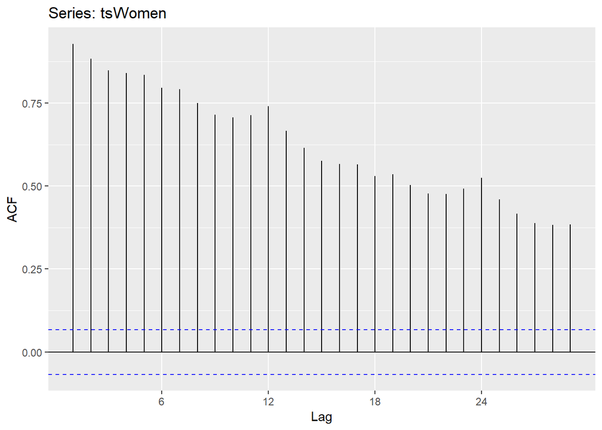

```r
ggAcf(tsWomen)
```

Тут видно, что есть тренд и периодичность (по годам).

Периодограмма ряда в логарифмической шкале:

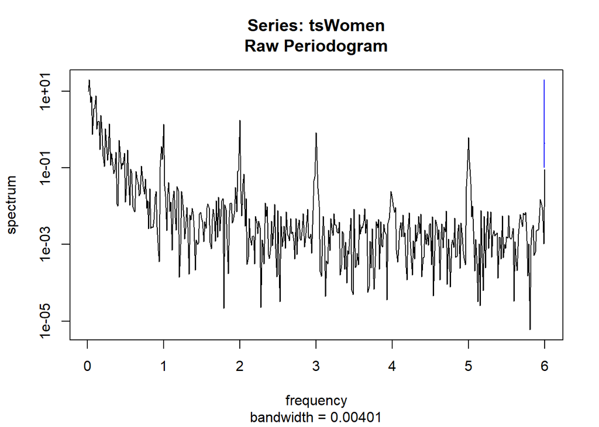

```r
spec.pgram(tsWomen,log="yes")
```

Периодограмма ряда в обычной шкале:

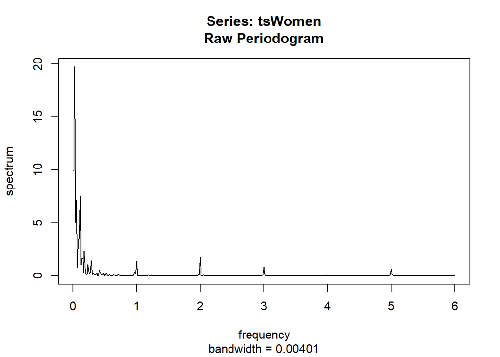

```r
spec.pgram(tsWomen,log="no")
```

Присутствует периодичность по годам, полугодиям и кварталам. Также есть небольшой пик для периода 2.4.

## 1.2 Выделение тренда разными способами

### 1.2.1 Скользящее среднее

Для выделения тренда при помощи скользящего среднего используем функцию filter() с параметром sides = 1, если хотим получить причинный фильтр (Causal). То же самое по умолчанию делает функция SMA(), результат приписывается последней точке.

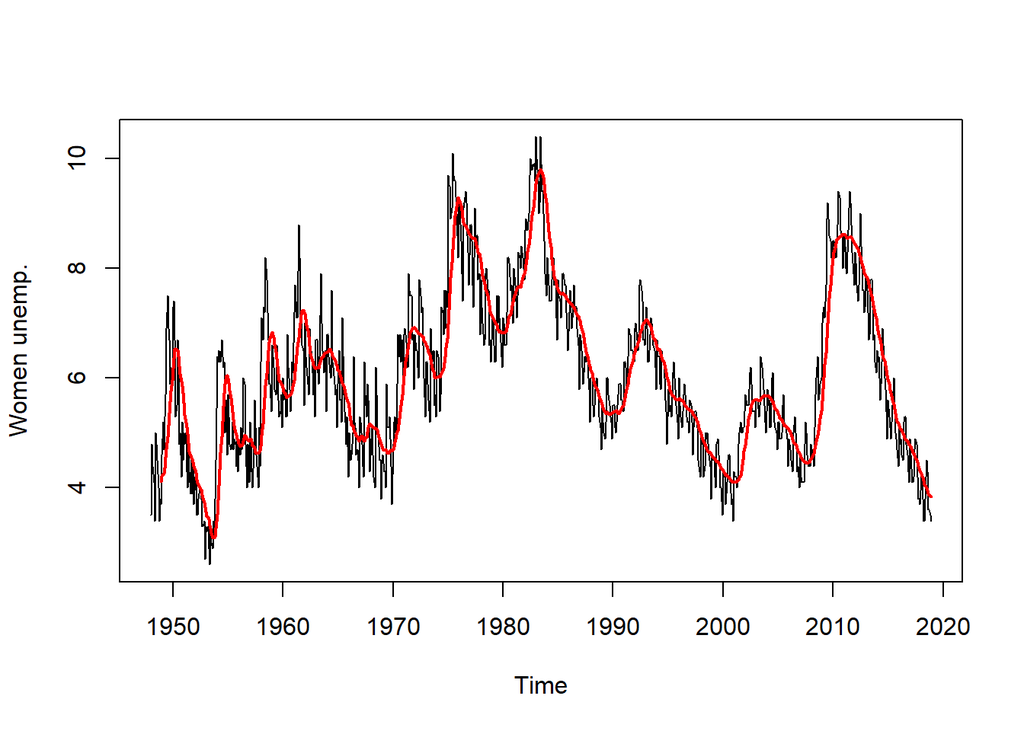

```r
ts.causal<-stats::filter(tsWomen, filter = rep(1/12, 12), sides = 1)
#ts.causal<-SMA(tsWomen, n = 12)
plot.ts(cbind(tsWomen, ts.causal), plot.type = 'single', col = c('black', 'red'),lwd=c(1,2), ylab = "Women unemp.")
```

АЧХ для такого фильтра:

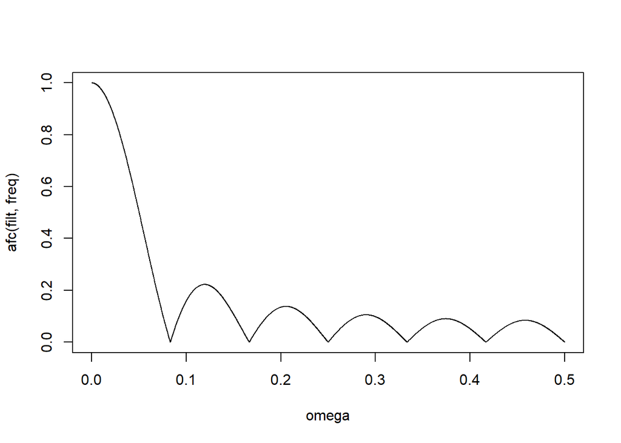

```r
filt<- rep(1/12, 12)
plot(afc(filt, freq) ~ omega, type = "l")
```

То есть скользящее среднее подавляет периодичность и высокие частоты (шум).

Если хотим скользящее среднее без сдвига для четного периода, берем длину окна T+1=13 и крайним частотам даем половинные веса. (Замечание: как раз так себя ведет функция ma() для случая четного периода, ее применение дает тот же результат, что применение функции filter() с вышеупомянутыми весами).

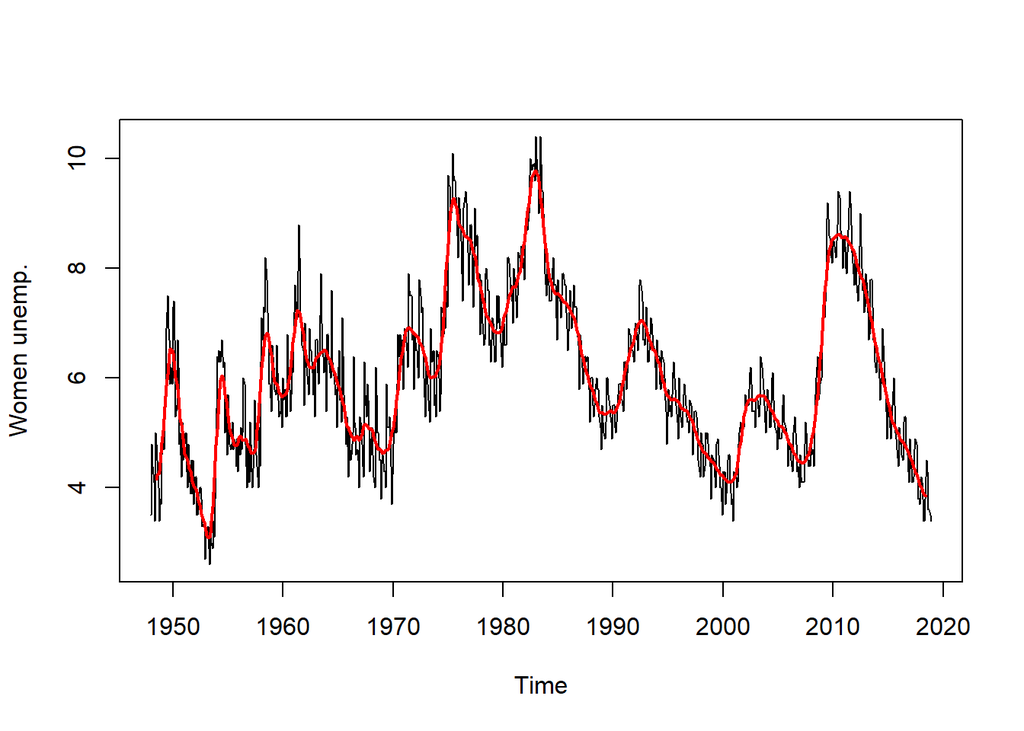

```r
ts.f13<-stats::filter(tsWomen, filter = c(1/24,rep(1/12,11),1/24), sides = 2)
#ts.f13<-ma(tsWomen, order = 12)
plot.ts(cbind(tsWomen, ts.f13), plot.type = 'single', col = c('black', 'red'),lwd=c(1,2), ylab = "Women unemp.")
```

Остатки (относительно тренда, выделенного последним фильтром):

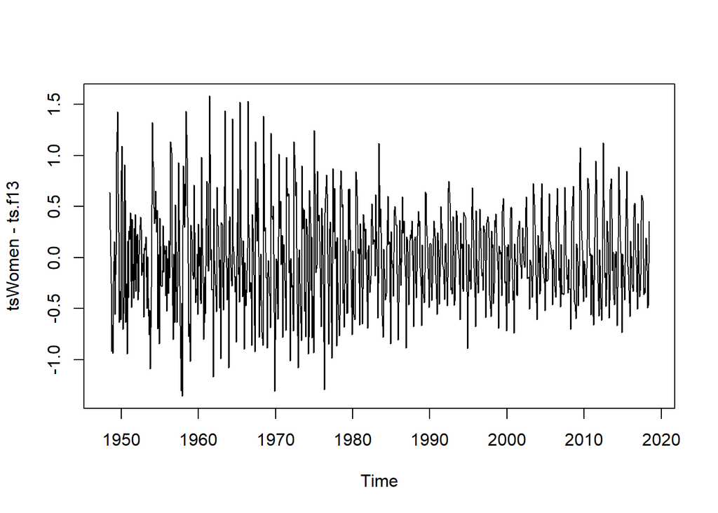

```r
plot(tsWomen-ts.f13, type="l")
```

Периодограмма остатков:

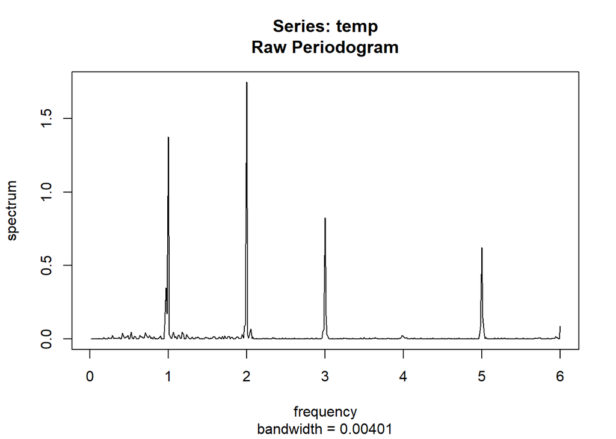

```r
temp<-ts(tsWomen[-c(1:6,847:852)]-ts.f13[-c(1:6,847:852)],frequency = 12)
spec.pgram(temp,log="no")
```

По периодограмме можно сказать, что мы прилично выделили тренд. Остался шум+периодичность.

Если возьмем окно побольше:

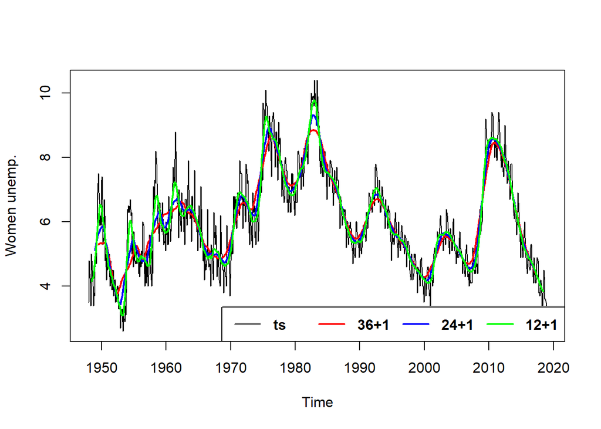

```r
ts.f25<-stats::filter(tsWomen, filter = c(1/48,rep(1/24,23),1/48), sides = 2)
ts.f37<-stats::filter(tsWomen, filter = c(1/72,rep(1/36,35),1/72), sides = 2)
plot.ts(cbind(tsWomen,ts.f37,ts.f25,ts.f13), plot.type = 'single', col = c('black', 'red','blue','green'),lwd=c(1,2,2,2), ylab = "Women unemp.")
legend("bottomright",paste(c("ts","36+1","24+1","12+1")), col = c('black', 'red','blue','green'),lty=1,lw=c(1,2,2,2),text.font = 2,horiz=TRUE)
```

При увеличении длины окна до 36+1 (и далее) сильно увеличивается смещение (особенно в левой части ряда), так что оставляем длину окна T=12+1 (тренд с длиной окна 24+1, в принципе, не так уж сильно смещается, его использование тоже возможно).

### 1.2.2 Скользящая медиана

Вряд ли в нашем случае имеет смысл заменять среднее медианой, учитывая непонятное поведение шума (можем получить сильное смещение). Но попробуем.

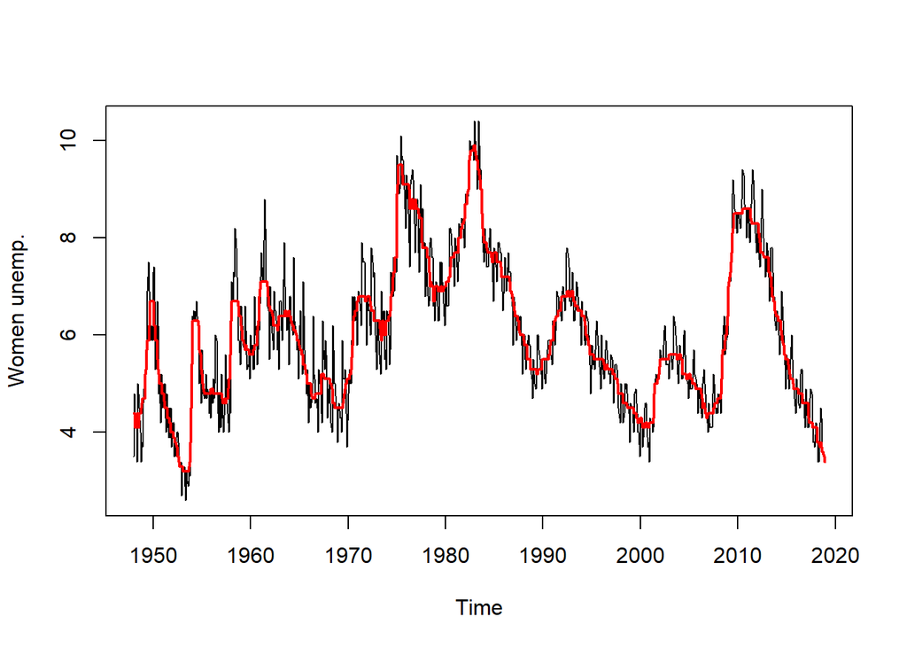

```r
mmed <- runmed(tsWomen,13)
plot.ts(cbind(tsWomen, mmed), plot.type = 'single', col = c('black', 'red'),lwd=c(1,2), ylab = "Women unemp.")
```

С целью избавления от возможных аутлаеров можно сначала применить скользящую медиану с небольшим окном (это уменьшит влияние выбросов), а потом применить скользящее среднее.

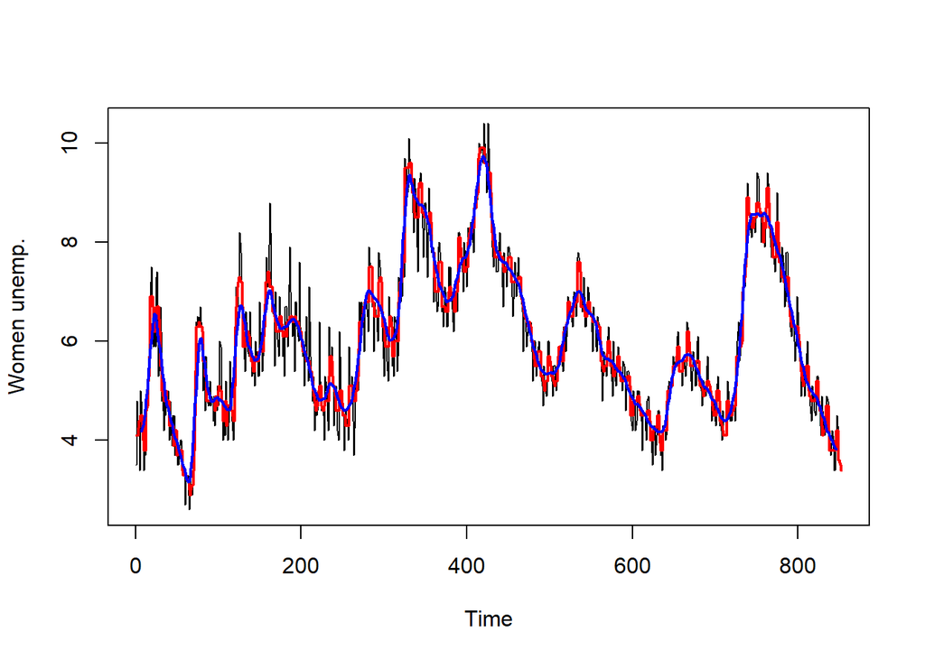

```r
mmed <- runmed(tsWomen,5)
mean.mmed<-stats::filter(mmed, filter = c(1/24,rep(1/12,11),1/24), sides = 2)
plot(cbind(as.numeric(tsWomen), mmed, mean.mmed), plot.type = 'single', col = c('black', 'red','blue'),lwd=c(1,2,2), ylab = "Women unemp.")
```

Интересно сравнить результат двух шагов (медиана+среднее) с результатом после одного шага (сразу среднее):

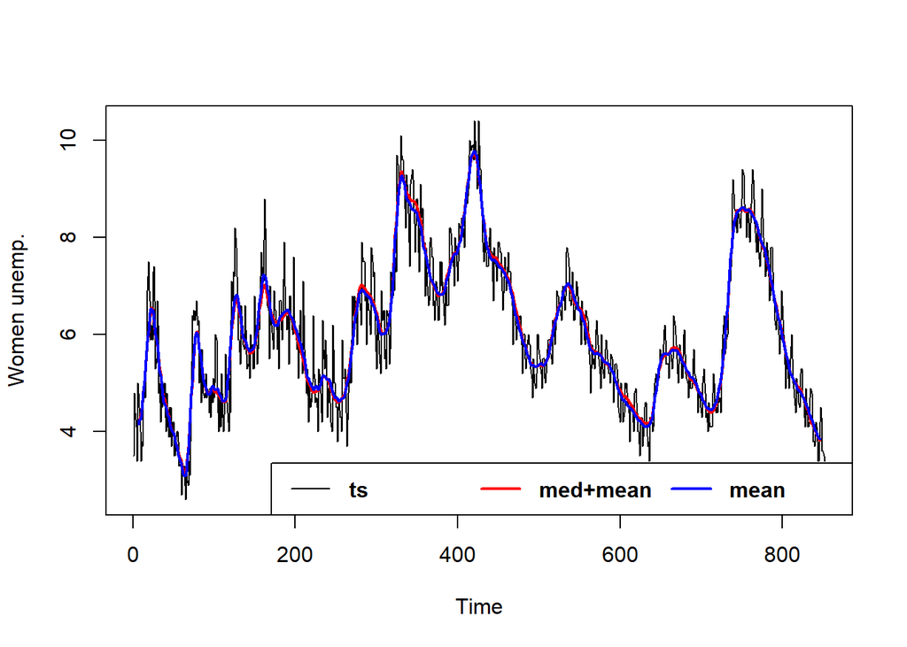

```r
plot(cbind(as.numeric(tsWomen), mean.mmed,as.numeric(ts.f13)), plot.type = 'single', col = c('black', 'red','blue'),lwd=c(1,2,2),  ylab = "Women unemp.")
legend("bottomright",paste(c("ts","med+mean","mean")), col = c('black', 'red','blue'),lty=1,lw=c(1,2,2),text.font = 2,horiz=TRUE)
```

Разницы почти не заметно.

### 1.2.3 Регрессия

Сначала еще раз посмотрим на наш ряд:

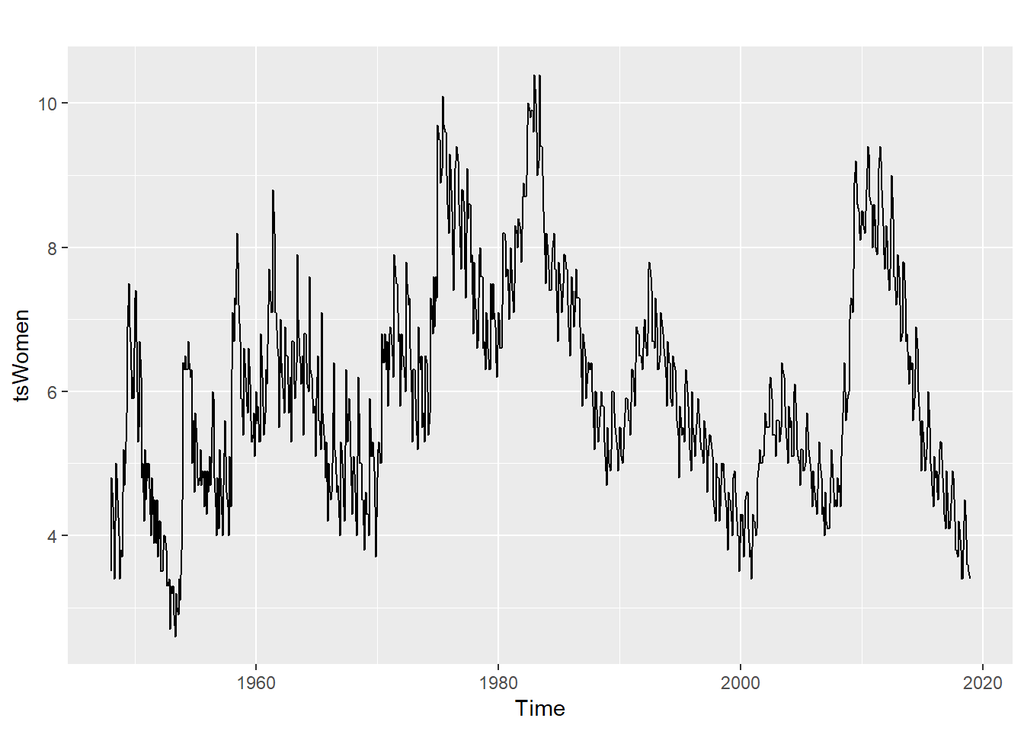

```r
autoplot(tsWomen)
```

На простую линейную регрессию надежды никакой нет. У нас нет постоянного роста в каком-то направлении, ряд туда-сюда болтается. Можно попробовать полиномиальную регрессию, возможно, что-то получится.

Начнем все равно с линейной регрессии (убедимся, что тренд она выделяет не очень). Проведем линейную регрессию значения временного ряда в точке по моменту времени (1,2,3,… ).

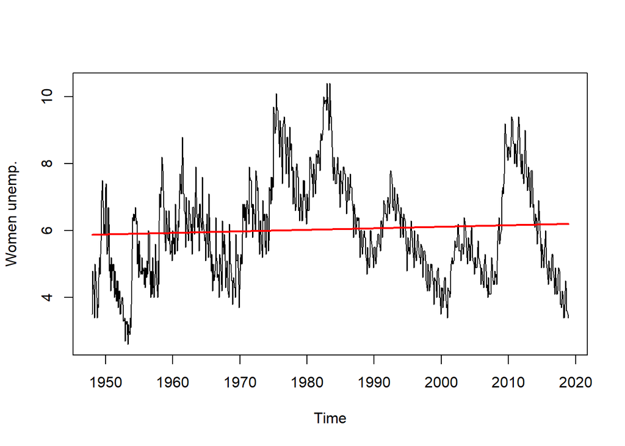

```r
trModel <- lm(tsWomen ~ c(1:length(tsWomen)),data = tsWomen)
plot.ts(cbind(tsWomen, trModel$fitted.values), plot.type = 'single', col = c('black', 'red'),lwd=c(1,2), ylab = "Women unemp.")
```

Линейная регрессия в данном случае почти незначима (линия регрессии практически константа):

```r
trModel$coefficients
```

```
##          (Intercept) c(1:length(tsWomen))
##         5.8756340235         0.0003804848
```

Периодограмма остатков:

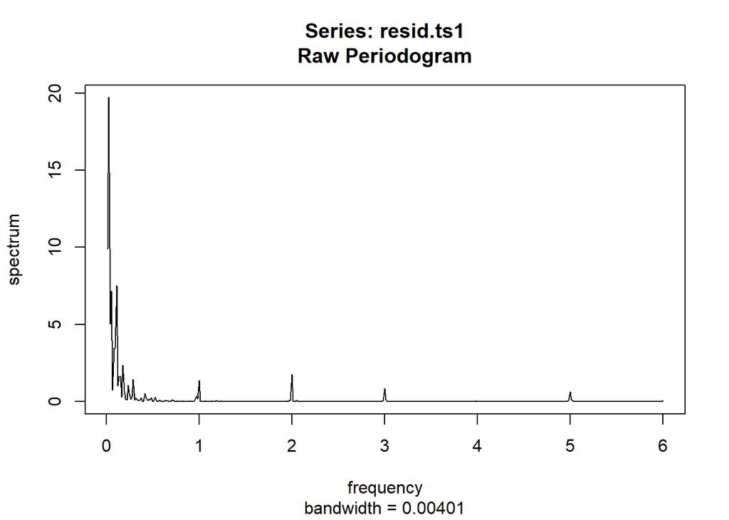

```r
resid.ts1<-ts(resid(trModel),frequency = 12)
spec.pgram(resid.ts1,log="no")
```

Ну да, все очень плохо, конечно. Тренд на месте.

Полиномиальная регрессия. Возьмем полиномом 6го порядка.

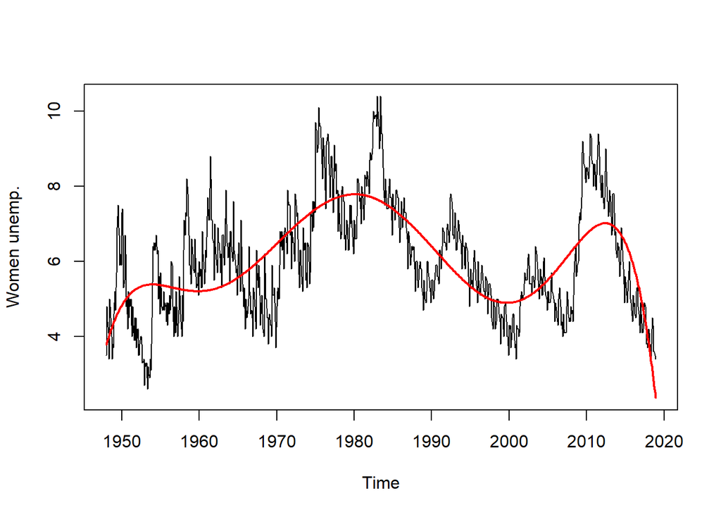

```r
trModel6<-lm(tsWomen~poly(c(1:length(tsWomen)),6),data=tsWomen)
plot.ts(cbind(tsWomen, trModel6$fitted.values), plot.type = 'single', col = c('black', 'red'),lwd=c(1,2), ylab = "Women unemp.")
```

Остатки

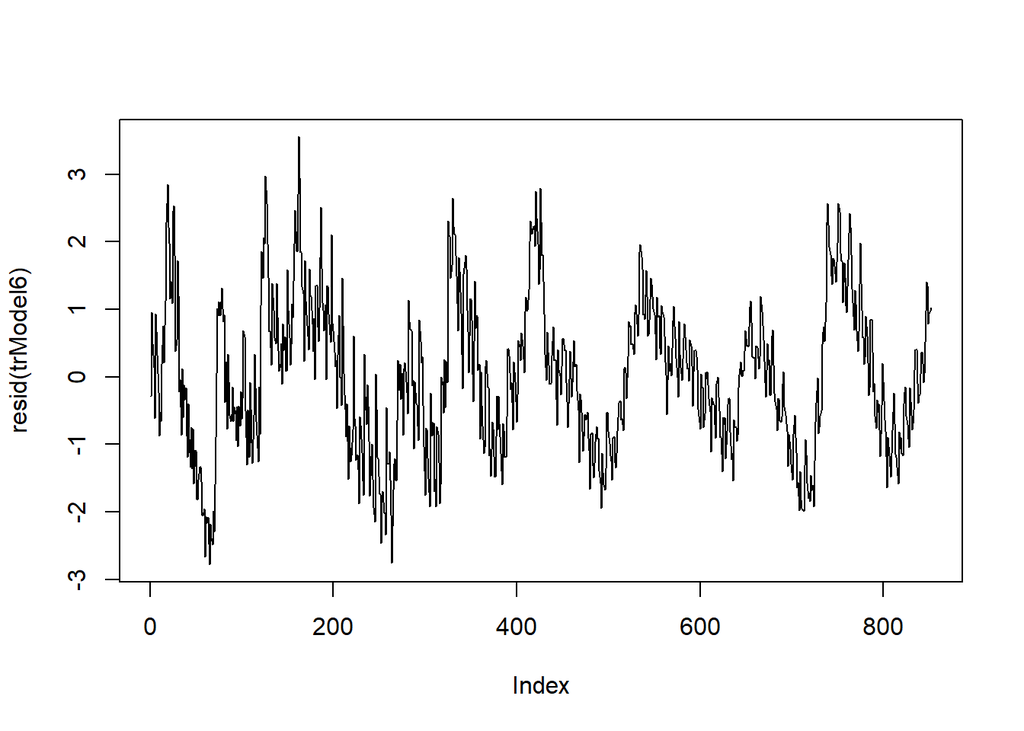

```r
plot(resid(trModel6), type="l")
```

В остатках явно видны куски неудаленного тренда (это понятно и по предыдущему графику). Так что 6й степени полинома недостаточно.

Периодограмма остатков:

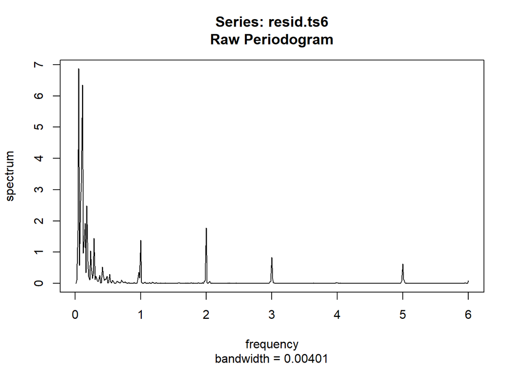

```r
resid.ts6<-ts(resid(trModel6),frequency = 12)
spec.pgram(resid.ts6,log="no")
```

Увеличим степень полинома до … 26й степени.

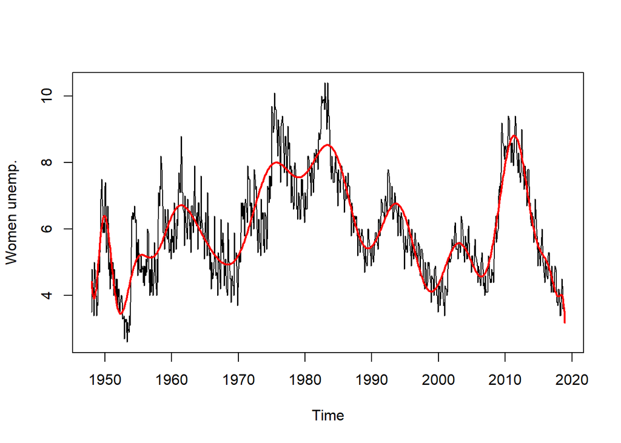

```r
trModel26<-lm(tsWomen~poly(c(1:length(tsWomen)),26),data=tsWomen)
plot.ts(cbind(tsWomen, trModel26$fitted.values), plot.type = 'single', col = c('black', 'red'),lwd=c(1,2), ylab = "Women unemp.")
```

Выглядит уже более менее неплохо.

Остатки

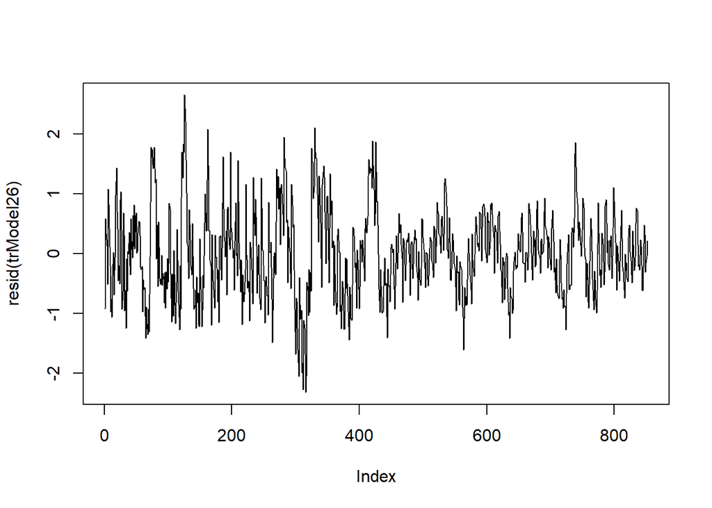

```r
plot(resid(trModel26), type="l")
```

Но в остатках по-прежнему есть тренд.

Периодограмма остатков:

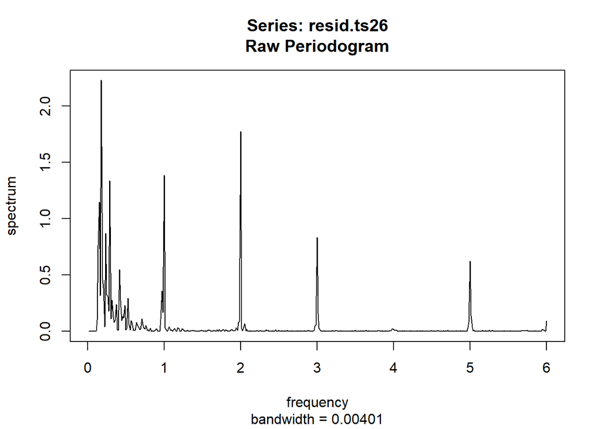

```r
resid.ts26<-ts(resid(trModel26),frequency = 12)
spec.pgram(resid.ts26,log="no")
```

Стало лучше, чем в случае полинома 6й степени, совсем низкие частоты выделены в тренд, но все же регрессия довольно грубо делает и для нашего тренда не очень подходит.

### 1.2.4 Локальная регрессия

Посмотрим на результаты локальной регрессии при разных значениях параметра span.

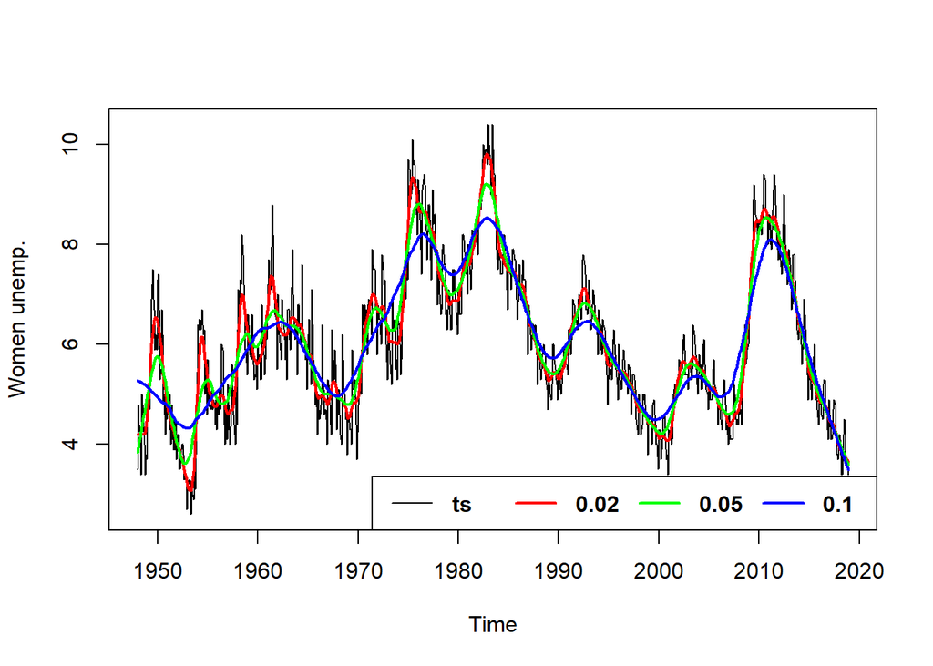

```r
loess.Model.02 <- loess(tsWomen ~ c(1:length(tsWomen)),data = tsWomen,span = 0.02,degree = 1)
loess.Model.05 <- loess(tsWomen ~ c(1:length(tsWomen)),data = tsWomen,span = 0.05,degree = 1)
loess.Model.1 <- loess(tsWomen ~ c(1:length(tsWomen)),data = tsWomen,span = 0.1,degree = 1)
plot.ts(cbind(tsWomen, loess.Model.02$fitted,loess.Model.05$fitted,loess.Model.1$fitted), plot.type = 'single', col = c('black', 'red','green','blue'),lwd=c(1,2,2,2), ylab = "Women unemp.")
legend("bottomright",paste(c("ts","0.02","0.05","0.1")), col = c('black', 'red','green','blue'),lty=1,lw=c(1,2,2,2),text.font = 2,horiz=TRUE)
```

Понятно, что чем span меньше, тем результат больше похож на исходный ряд. Но так как наша цель его все-таки как-то сгладить – будем брать не слишком маленькое значение span. На графике красная линия слишком отвечает всем колебаниям ряда (и из-за этого очень неровная и болтающаяся), а синяя наоборот (особенно слева). Возьмем в итоге span = 0.05.

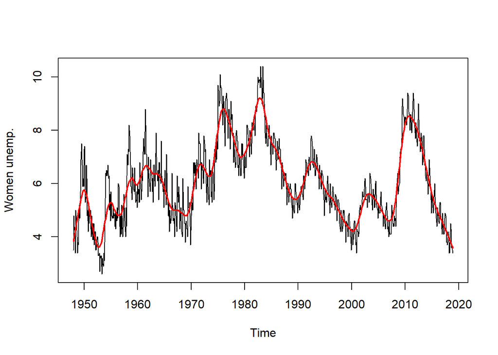

```r
plot.ts(cbind(tsWomen, loess.Model.05$fitted), plot.type = 'single', col = c('black', 'red'),lwd=c(1,2), ylab = "Women unemp.")
```

Периодограмма остатков:

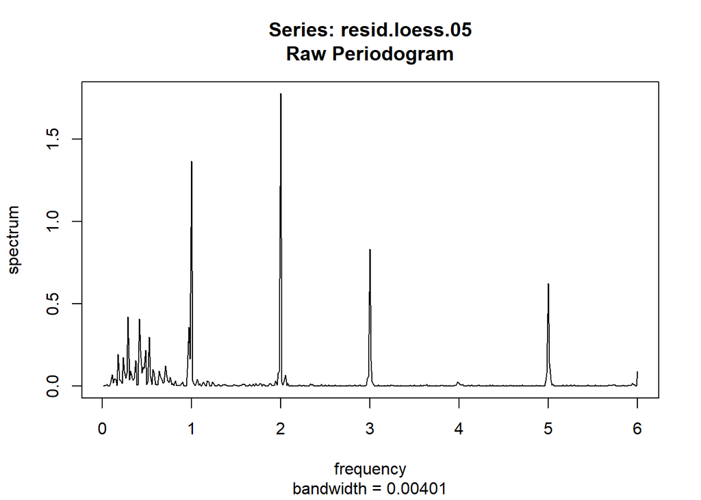

```r
resid.loess.05<-ts(resid(loess.Model.05),frequency = 12)
spec.pgram(resid.loess.05,log="no")
```

Ага. Вроде как и убрали, но не совсем. Еще остались низкочастотные составляющие. Если все же возьмем span = 0.02, то периодограмма покажет, что тренд выделяется более тщательно.

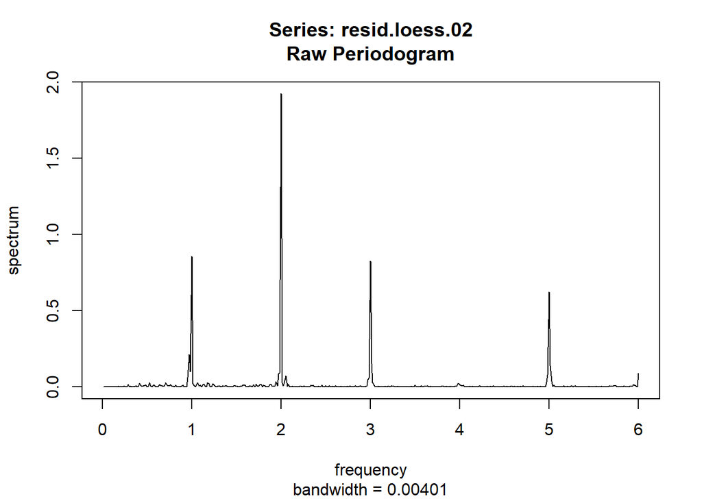

```r
resid.loess.02<-ts(resid(loess.Model.02),frequency = 12)
spec.pgram(resid.loess.02,log="no")
```

### 1.2.5 Процедура на основе локальной регрессии для борьбы с аутлаерами

Робастная версия:

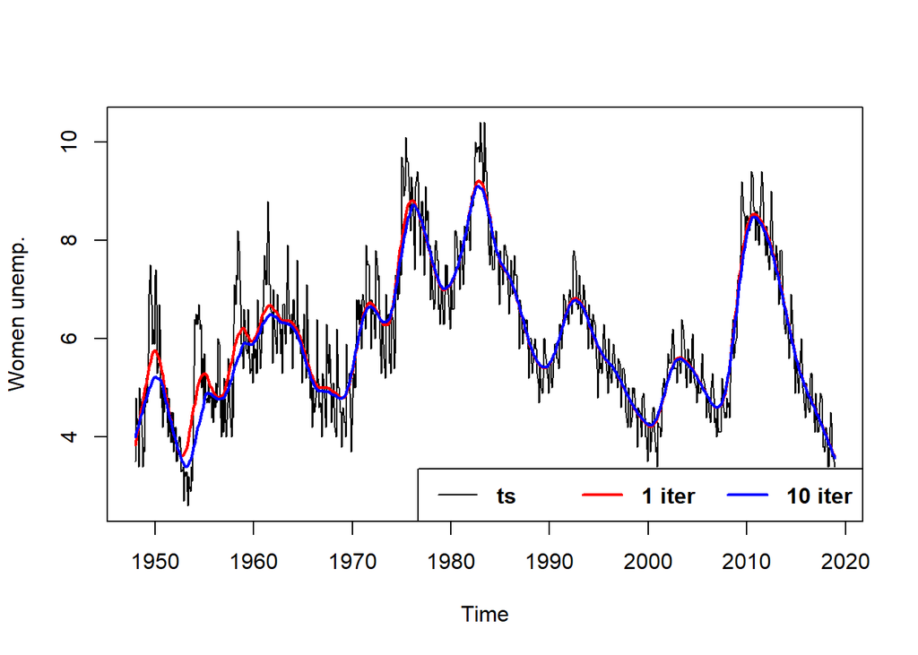

```r
loess.Model.05.iter <- loess(tsWomen ~ c(1:length(tsWomen)),data = tsWomen,span = 0.05,degree = 1,family = "symmetric",control = loess.control(iterations = 10))

plot.ts(cbind(tsWomen, loess.Model.05$fitted,loess.Model.05.iter$fitted), plot.type = 'single', col = c('black', 'red','blue'),lwd=c(1,2,2), ylab = "Women unemp.")
legend("bottomright",paste(c("ts","1 iter","10 iter")), col = c('black', 'red','blue'),lty=1,lw=c(1,2,2),text.font = 2,horiz=TRUE)
```

Разница видна особенно слева. Как мы замечали и раньше, в левой части ряда у нас колебания сильнее, так что это логично. + похоже, что в левой части вторая производная тренда больше (резкие перегибы), поэтому остатки больше. Внешний цикл процедуры приписывает маленькие веса пикам в левой части и таким образом постепенно смещается вниз.

### 1.2.6 Hodrick-Prescott filter (HP-filter)

При помощи изменения $\lambda$ регулируем, что для нас важнее, похожесть на исходный ряд или гладкость (маленькая вторая производная). Для рядов с сезонностью рекомендуется использовать $\lambda=129600$.

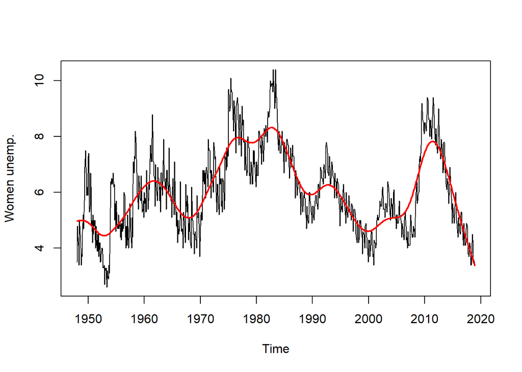

```r
hp.Women<-hpfilter(tsWomen,type = "lambda",freq = 129600)
plot.ts(cbind(tsWomen, hp.Women$trend), plot.type = 'single', col = c('black', 'red'),lwd=c(1,2), ylab = "Women unemp.")
```

Периодограмма:

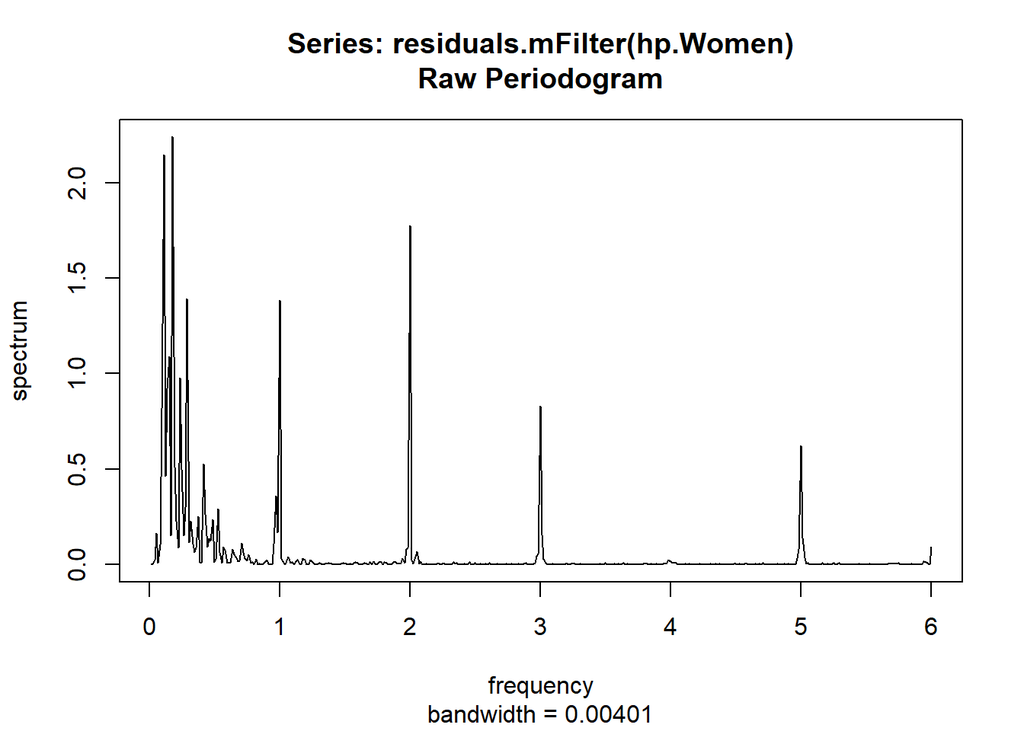

```r
spec.pgram(residuals.mFilter(hp.Women),log="no")
```

Фильтр убрал только совсем низкие частоты.

Уменьшаем $\lambda$ => увеличиваем похожесть, уменьшаем гладкость. Например, с $\lambda=3000$ имеем

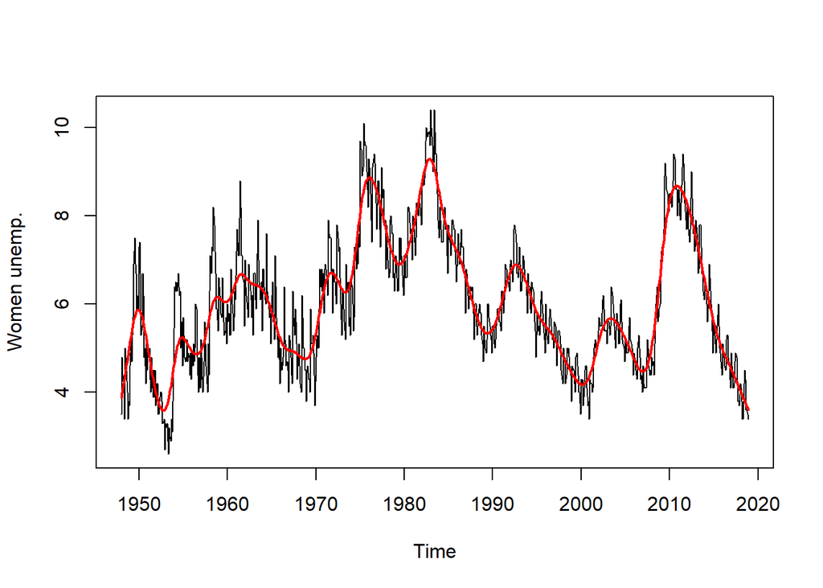

```r
hp.Women3000<-hpfilter(tsWomen,type = "lambda",freq = 3000)
plot.ts(cbind(tsWomen, hp.Women3000$trend), plot.type = 'single', col = c('black', 'red'),lwd=c(1,2), ylab = "Women unemp.")
```

Периодограмма:

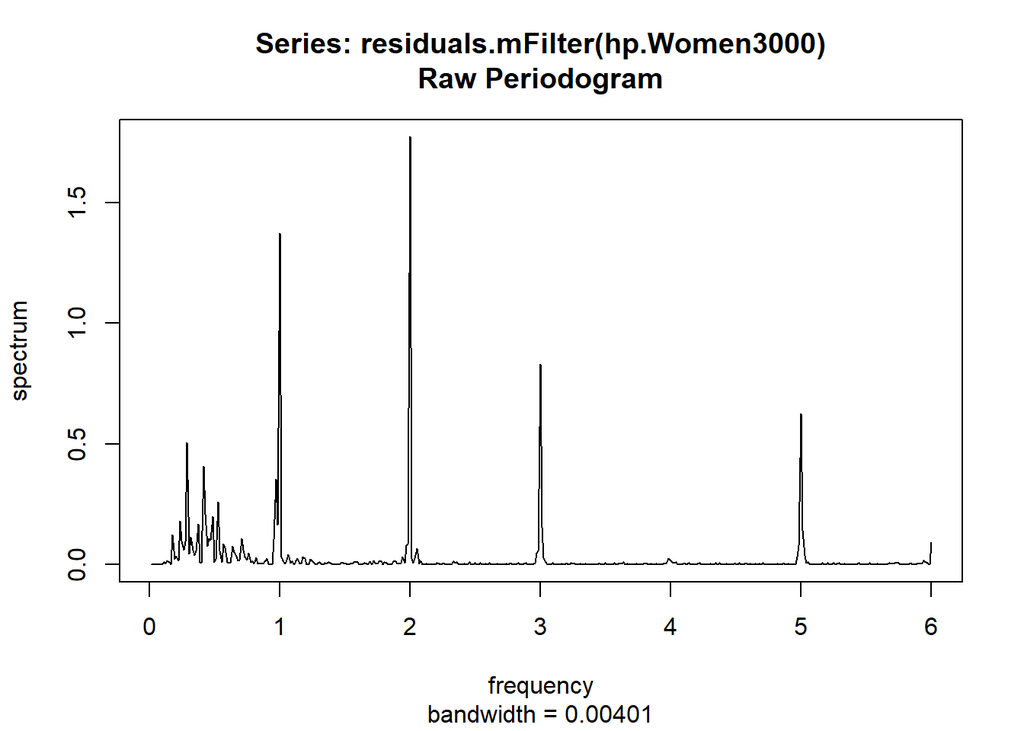

```r
spec.pgram(residuals.mFilter(hp.Women3000),log="no")
```